# TaD_Assignment_2

Laura Menicacci

2022-11-13

```r
# setwd('C:\\Users\\laura\\OneDrive\\Documenti\\LAURA\\HERTIE 22-23\\Text_as_Data_class')

getwd()
```

```
## [1] "C:/Users/laura/OneDrive/Documenti/LAURA/HERTIE 22-23/Text_as_Data_class/ass_2_tad_topicmodeling"
```

## Download data

```r
mp_setapikey(key.file = "C:\\Users\\laura\\OneDrive\\Documenti\\LAURA\\HERTIE 21-22\\Introduction to DS\\manifesto_apikey.txt")

us_raw <- read_csv('C:\\Users\\laura\\OneDrive\\Documenti\\LAURA\\HERTIE 22-23\\Text_as_Data_class\\ass_2_tad_topicmodeling\\MPDataset_MPDS2022a.csv')
us_raw <- us_raw %>%
  filter(countryname == 'United States')
```

## Filter dataset by country & create corpus

```r
us <- mp_availability(countryname == "United States")
```

```
## Connecting to Manifesto Project DB API...
## Connecting to Manifesto Project DB API... corpus version: 2022-1
## Connecting to Manifesto Project DB API...
## Connecting to Manifesto Project DB API... corpus version: 2022-1
## Connecting to Manifesto Project DB API... corpus version: 2022-1
```

```r
e <- mp_corpus(us)
```

```
## Connecting to Manifesto Project DB API... corpus version: 2022-1
```

```r
e_corpus <- e %>%
  as.data.frame(with.meta = TRUE) %>%
  corpus(docid_field = "manifesto_id", unique_docnames = FALSE) %>%
  corpus()

e_corpus %>%
  docvars()
```

```
##      cmp_code eu_code  pos party   date language source has_eu_code
## 1        <NA>    <NA>    1 61320 196011  english   CEMP       FALSE
## 2        <NA>    <NA>    1 61320 196411  english   CEMP       FALSE
## 3        <NA>    <NA>    1 61320 196811  english   CEMP       FALSE
## 4        <NA>    <NA>    1 61320 197211  english   CEMP       FALSE
## 5        <NA>    <NA>    1 61320 197611  english   CEMP       FALSE
## 6        <NA>    <NA>    1 61320 198011  english   CEMP       FALSE
## 7        <NA>    <NA>    1 61320 198411  english   CEMP       FALSE
## 8        <NA>    <NA>    1 61320 198811  english   CEMP       FALSE
## 9        <NA>    <NA>    1 61320 199211  english MARPOR       FALSE
## 10        202    <NA>    2 61320 199211  english MARPOR       FALSE
## 11        201    <NA>    3 61320 199211  english MARPOR       FALSE
## 12        605    <NA>    4 61320 199211  english MARPOR       FALSE
## 13        000    <NA>    5 61320 199211  english MARPOR       FALSE
## 14        606    <NA>    6 61320 199211  english MARPOR       FALSE
```

[output cut: 33322 more lines]

## What years, countries and parties are included in the dataset? How many texts do you have for each of these

```r
# 55 documents

us_raw %>% group_by(edate) %>% count()
```

```
## # A tibble: 26 × 2
## # Groups:   edate [26]
##    edate          n
##    <chr>      <int>
##  1 02/11/1920     2
##  2 02/11/1948     4
##  3 02/11/1976     2
##  4 02/11/2004     2
##  5 03/11/1936     2
##  6 03/11/1964     2
##  7 03/11/1992     2
##  8 03/11/2020     2
##  9 04/11/1924     3
## 10 04/11/1952     2
## # … with 16 more rows
```

```r
table(us_raw$year)
```

```
## < table of extent 0 >
```

```r
table(us_raw$countryname)
```

```
##
## United States
##            55
```

```r
table(us_raw$party)
```

```
##
## 61320 61620 61621 61622 61911
##    26    26     1     1     1
```

```r
us_raw %>% group_by(countryname) %>% count()
```

```
## # A tibble: 1 × 2
## # Groups:   countryname [1]
##   countryname       n
##   <chr>         <int>
## 1 United States    55
```

```r
us_raw %>% group_by(party) %>% count()
```

```
## # A tibble: 5 × 2
## # Groups:   party [5]
##   party     n
##   <dbl> <int>
## 1 61320    26
## 2 61620    26
## 3 61621     1
## 4 61622     1
## 5 61911     1
```

# Explorative analysis: explore all codes taken into consideration

## Prepare your data for topic modelling by creating a document feature matrix. Describe the choices you make here, and comment on how these might affect your final result.

Here I tokenize the manifesto removing all punctuation and all numbers, and lemmatizing the words. I think this is a more powerful methods because it creates a better vocabulary.  
I use quanteda functions to create the dfm and drop all quasi-sentences with headline codes (“H”), uncoded (“0”,“000”) and with codes missing (NA). Then I filter them for the cmp codes I am interested in, which are the following:

- 503 Equality: Positive
- 501 Environmental protection

Of course, reducing the documents to only the coded quasi sentences will have an impact as there are many sentences present that are not coded. This represents implicitly a selection bias.

```r
tokenized_manifesto <- e_corpus %>%
  tokens() %>%
  tokens(remove_punct = TRUE, remove_numbers = TRUE) %>%
  tokens_tolower() %>%
  tokens_remove(stopwords("english")) %>%
  tokens_remove(c("will", "american")) %>%
  tokens_replace(pattern = lexicon::hash_lemmas$token, replacement = lexicon::hash_lemmas$lemma)
```

## Dfm ready to be used

```r
manifesto_dfm <- tokenized_manifesto %>%
  dfm() %>%
  dfm_subset(!(cmp_code %in% c("H", "", "0", "000", NA))) %>%
  dfm_subset(cmp_code %in% c('503', '501'))

manifesto_dfm$id %>% unique() # number of text in the final preprocessed manifesto
```

```
##  [1] "61320_199211" "61320_200411" "61320_201211" "61320_201611" "61320_202011"
##  [6] "61620_200411" "61620_200811" "61620_201211" "61620_201611" "61620_202011"
```

## some exploratory plotting

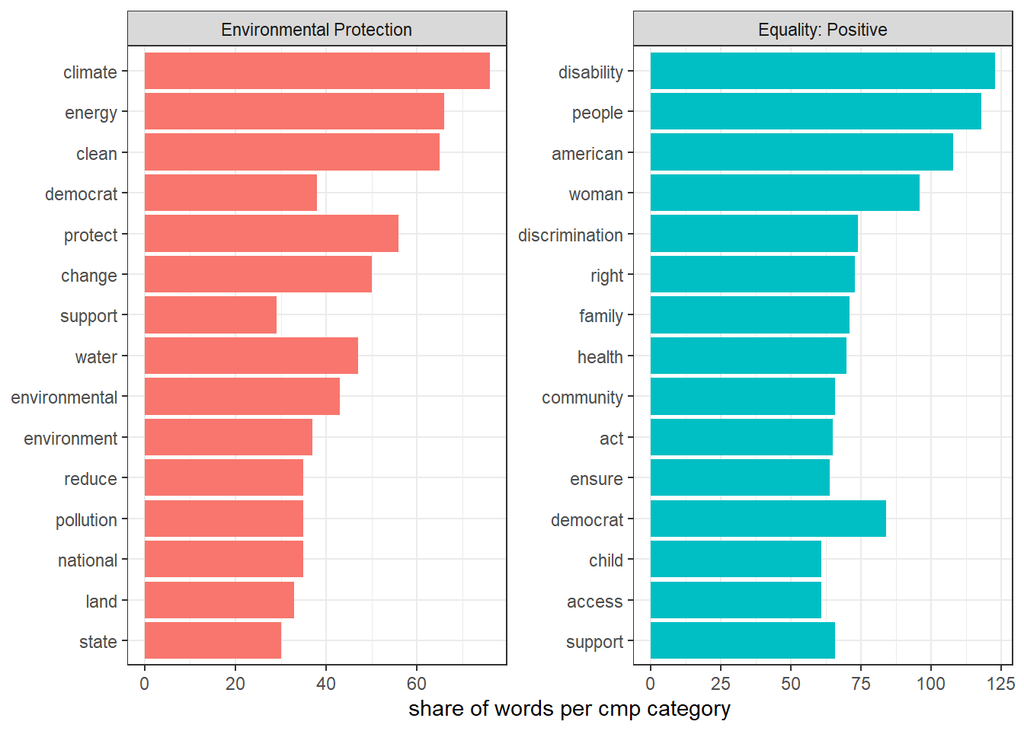

```r
manif_plot_cmp <- manifesto_dfm %>% dfm_group(cmp_code)

library(quanteda.textstats)
feature_frequencies_cat <- manif_plot_cmp %>% textstat_frequency(n = 15, group = cmp_code)

feature_frequencies_cat %>%
  mutate(group = case_when(
    group == "503" ~ "Equality: Positive",
    group == "501" ~ "Environmental Protection")) %>%
  ggplot(aes(x = reorder(feature, frequency), y = frequency, fill = group)) +
  geom_col(show.legend = FALSE) +
  labs(x = NULL, y = "share of words per cmp category") +
  facet_wrap(~group, ncol = 2, scales = "free") +
  coord_flip() +
  theme_bw()
```

```r
# ggsave('plots/top_words_cmp.png', width = 12, height = 8)
```

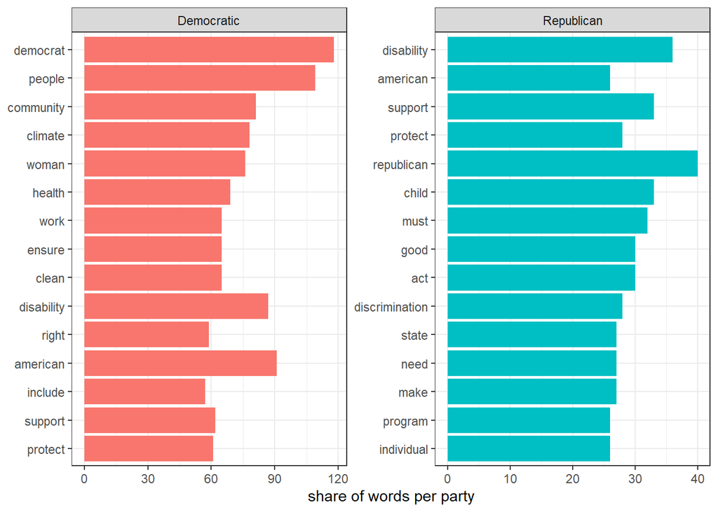

```r
manif_plot_party <- manifesto_dfm %>% dfm_group(party)

feature_frequencies_cat <- manif_plot_party %>% textstat_frequency(n = 15, group = party)

feature_frequencies_cat %>%
  mutate(group = case_when(
    group == "61320" ~ "Democratic",
    group == "61620" ~ "Republican"
  )) %>%
  ggplot(aes(x = reorder(feature, frequency), y = frequency, fill = group)) +
  geom_col(show.legend = FALSE) +
  labs(x = NULL, y = "share of words per party") +
  facet_wrap(~group, ncol = 2, scales = "free") +
  coord_flip() +
  theme_bw()
```

```r
# ggsave('plots\top_words_party.png', width = 12, height = 8)
```

# Describe a research question you want to explore with topic modelling. Comment on how answerable this is with the methods and data at your disposal.

## Research question:

1. Looking out for connection points in between climate change and equality themes in the political manifestos in the United States.
- Can environmental protection and elements of social welfare as equality be considered similar?

In general, these can be considered as two separated topics. On the one side, climate change is a relatively new topic, as it only started to be present in politics in the last 20/30 years. We can recall the first political commitments to the conference hosted in Rio de Janeiro in 1992, and then the ratification of the Kyoto Protocol in 1997. The United States pushed at the beginning for the creation of international debate around climate change, however they did not ratify Kyoto in the beginning.

For what concerns equality, especially gender equality, this is a much more old political thematic. In particular, the US are famous for being the country that mostly contributed to the third feminist wave. However, the codification made by the ManifestoProject researchers it’s interesting because it implies an ‘inclusive’ equality, not only a gender equality. This is particularly interesting in the context of climate change because recent studies affirm that race and pollution are correlated, meaning that often in the US, black people are more affected by climate change as they more often live close to hazardous waste (Fumes Across the Fence-Line: The Health Impacts of Air Pollution from Oil & Gas Facilities on African American Commmunities, 2017 NAACP).

But let’s get into the research question: I am interested in seeing whether in the political manifestos of the last 30 years, US parties, especially the democrats, addressed potential electors using similar words for the topics of equality and climate change.

I am interested in seeing what is the political role when parties write their manifestos, and whether they could have some political connections or correlations.

In the context of the US, this are themes particularly covered by the Democratic party. But how do they talk about it? In which way they use such topics? Can they have a similar political role? If yes, can this be expressed in the way they talk about it?

Topic modeling will help to understand if these topics are classified as extremely distinct or they have some overlaps.

In this assignment I will inspect possible connections using LDA.

After filtering for the two codes, we have 10 manifestos corresponding to the year range 1992 - 2020.

# Create a topic model using your data. Explain to a non-specialist what the topic model does. Comment on the choices you make here in terms of hyperparameter selection and model choice. How might these affect your results and the ability to answer your research question?

LDA is one of the most popular topic models. It is a probabilistic model. LDA assigns to each word, a probability to belong to a topic, and to each document (in this case the quasi-sentence), a probability to belong to a topic. This is done using a particular distribution, the Dirichlet distribution.

One of the hyperparameters is the number of topics, which can be either arbitrarily decided through a trial and error process (manual grid search), or calculated evaluating the log-likelihood for the k number of topics using, the harmonic mean as it is done in Ponweiser, M. (2012).

In this case, the manual grid search process will be used.

### Topic modeling: inspecting topic similarity with lda function in topicmodels package

```r
library(topicmodels)

lda_tidy <- LDA(manifesto_dfm, 8)

library(reshape2)
```

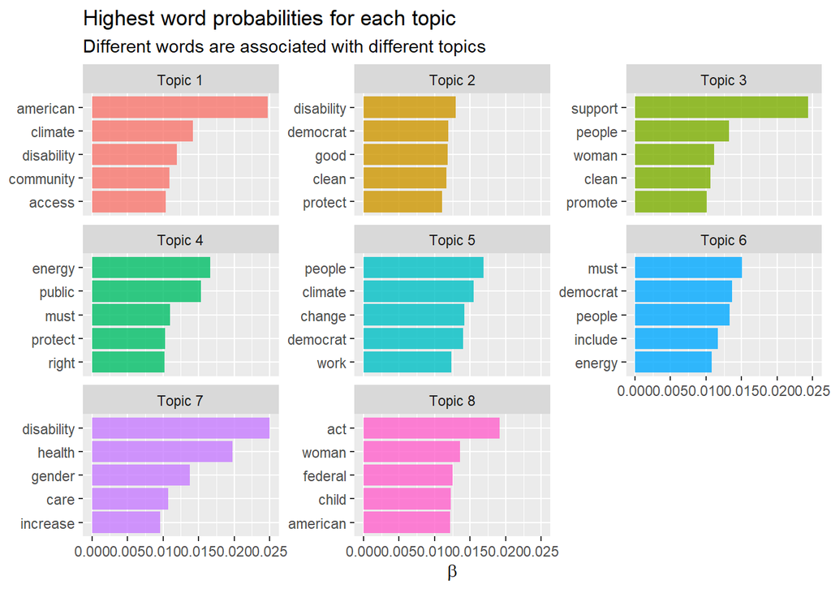

```r
library(tidytext)

topic_words <- tidy(lda_tidy, matrix="beta") %>%
  group_by(topic) %>%
  slice_max(beta, n = 5) %>%
  ungroup() %>%
  arrange(topic, -beta)

topic_words %>%
  mutate(topic = paste0("Topic ", topic),
           term = reorder_within(term, beta, topic)) %>%
  ggplot(aes(term, beta, fill = as.factor(topic))) +
  geom_col(alpha = 0.8, show.legend = FALSE) +
  facet_wrap(~ topic, scales = "free_y") +
  coord_flip() +
  scale_x_reordered() +
  labs(x = NULL, y = expression(beta),
         title = "Highest word probabilities for each topic",
         subtitle = "Different words are associated with different topics")
```

# Describe the topic model. What topics does it contain? How are these distributed across the data?

An important remark to make is that LDA is a probabilistic model, which means that if it is re-trained it multiple times it will output different results each time. An ideal practice would be to run the model multiple times and then produce an average of the posterior probabilities, to understand better if there is coherence in the topic clustering.

During the trial and error process, a clustering with a decent separation was found with k = 8. Interesting observations: * often the word “woman” appears in the same topic with the word “support”, ensure. * often there is more than one topic dealing with environment, and one of the sometimes includes the word ‘gender’ or “community”. * When people or the community are addressed, often the word “woman” appears.

## Use your topic model to answer your research question by showing plots or statistical results. Discuss the implications of what you find, and any limitations inherent in your approach. Discuss how the work could be improved upon in future research.

```r
# lda visualization: https://knowledger.rbind.io/post/topic-modeling-using-r/
library(LDAvis)

topicmodels2LDAvis <- function(x, ...){
  post <- topicmodels::posterior(x)
  if (ncol(post[["topics"]]) < 3) stop("The model must contain > 2 topics")
  mat <- x@wordassignments
  json <- LDAvis::createJSON(
    phi = post[["terms"]],
    theta = post[["topics"]],
    vocab = colnames(post[["terms"]]),
    doc.length = slam::row_sums(mat, na.rm = TRUE),
    term.frequency = slam::col_sums(mat, na.rm = TRUE)
)
return(json)
}

json <- topicmodels2LDAvis(lda_tidy)
serVis(json)
```

Here I take the per document probabilities of the topics to dive deep into the topic distribution. How clear is the topic allocation per document according to the topic division?

```r
doc_x_topic <- as.data.frame(topicmodels::posterior(lda_tidy)$topics)
head(doc_x_topic) # probabilities of the first 5 documents to belong to that topic
```

```
##                          1         2         3         4         5         6
## 61320_199211.19  0.1255084 0.1245973 0.1208292 0.1202973 0.1198131 0.1354240
## 61320_199211.45  0.1231430 0.1234228 0.1264828 0.1247899 0.1271989 0.1257412
## 61320_199211.46  0.1243581 0.1252467 0.1237717 0.1235056 0.1251060 0.1240612
## 61320_199211.117 0.1233630 0.1197685 0.1240821 0.1302615 0.1231974 0.1227854
## 61320_199211.129 0.1273291 0.1228594 0.1237650 0.1232995 0.1239469 0.1246124
## 61320_199211.134 0.1240238 0.1196386 0.1200311 0.1180115 0.1270811 0.1234939
##                          7         8
## 61320_199211.19  0.1362310 0.1172996
## 61320_199211.45  0.1231523 0.1260691
## 61320_199211.46  0.1292091 0.1247417
## 61320_199211.117 0.1271039 0.1294383
## 61320_199211.129 0.1312685 0.1229193
## 61320_199211.134 0.1461073 0.1216125
```

## Distribution of documents per topics

```r
# Creates a dataframe to store the document id and the most likely topic

doc_x_topic <- as.data.frame(topicmodels::posterior(lda_tidy)$topics)
head(doc_x_topic) # probabilities of the first 5 documents to belong to that topic
```

```
##                          1         2         3         4         5         6
## 61320_199211.19  0.1255084 0.1245973 0.1208292 0.1202973 0.1198131 0.1354240
## 61320_199211.45  0.1231430 0.1234228 0.1264828 0.1247899 0.1271989 0.1257412
## 61320_199211.46  0.1243581 0.1252467 0.1237717 0.1235056 0.1251060 0.1240612
## 61320_199211.117 0.1233630 0.1197685 0.1240821 0.1302615 0.1231974 0.1227854
## 61320_199211.129 0.1273291 0.1228594 0.1237650 0.1232995 0.1239469 0.1246124
## 61320_199211.134 0.1240238 0.1196386 0.1200311 0.1180115 0.1270811 0.1234939
##                          7         8
## 61320_199211.19  0.1362310 0.1172996
## 61320_199211.45  0.1231523 0.1260691
## 61320_199211.46  0.1292091 0.1247417
## 61320_199211.117 0.1271039 0.1294383
## 61320_199211.129 0.1312685 0.1229193
## 61320_199211.134 0.1461073 0.1216125
```

```r
topics <- (topics(lda_tidy))
lda_topics <- as.data.frame(topics)

lda_topics <- dplyr::transmute(lda_topics, ManifestoId = rownames(lda_topics), Topic = topics)

head(lda_topics)
```

```
##                       ManifestoId Topic
## 61320_199211.19   61320_199211.19     7
## 61320_199211.45   61320_199211.45     5
## 61320_199211.46   61320_199211.46     7
## 61320_199211.117 61320_199211.117     4
## 61320_199211.129 61320_199211.129     7
## 61320_199211.134 61320_199211.134     7
```

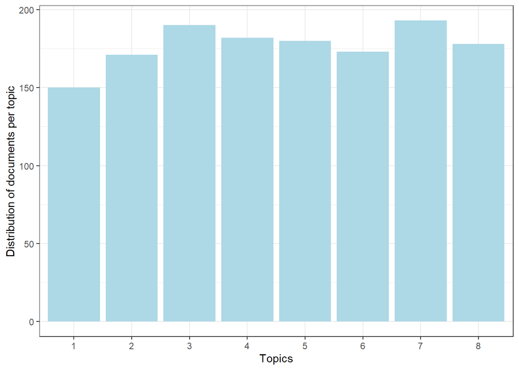

```r
lda_topics %>% mutate(Topic = as.factor(Topic)) %>%
  ggplot(aes(x = Topic)) + geom_bar(fill = 'lightblue') + ylab('Distribution of documents per topic') + xlab('Topics') + theme_bw()
```

## Correlation plot

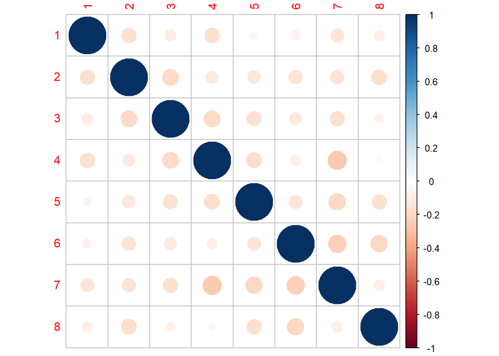

```r
prob_x_topic <- as.data.frame(topicmodels::posterior(lda_tidy)$topics)

library(corrplot)
c <- cor(prob_x_topic)
corrplot(c, method = "circle")
```

This could mean that either this is not a good way to evaluated this model in terms of my research question, or that simply the answer to my research question is a big *no*.

### Analyse coherence and prevalence

Here I will try another strategy, this time with a different LDA package, textminingR. I will also try to use difference metrics, meaning coherence and prevalence.

First subset the corpus by the codes of interest, then run the model.

```r
library(textmineR)
e_corpus_lda1 <- e_corpus %>%
  corpus_subset(!(cmp_code %in% c("H", "", "0", "000", NA))) %>%
  corpus_subset(cmp_code %in% c('501', '503')) %>%
  corpus_group(id)

dtm1 <- CreateDtm(doc_vec = e_corpus_lda1,
                   doc_names = e_corpus_lda1$id,
                   ngram_window = c(1,2),
                   stopword_vec = stopwords("en"),
                   verbose = F)
```

```
## as(<dgTMatrix>, "dgCMatrix") is deprecated since Matrix 1.5-0; do as(., "CsparseMatrix") instead
```

```r
lda1 <- FitLdaModel(dtm = dtm1,
                         k = 8, # number of topic
                         iterations = 50,
                         burnin = 5,
                         alpha = 0.1,
                         beta = 0.05,
                         optimize_alpha = T,
                         calc_likelihood = T,
                         calc_coherence = T,
                         calc_r2 = T)
```

Inspect results and plot coherence and prevalence

Here, coeherence tell us how associated words are in a topic. Prevalence tells us insted the most frequent topics in the corpus.

```r
top_terms <- GetTopTerms(phi = lda1$phi, M = 10)
top_terms
```

```
##       t_1         t_2            t_3            t_4
##  [1,] "people"    "disabilities" "americans"    "will"
##  [2,] "will"      "must"         "will"         "democrats"
##  [3,] "public"    "religious"    "low_income"   "communities"
##  [4,] "change"    "children"     "based"        "color"
##  [5,] "clean"     "access"       "equal"        "climate"
##  [6,] "american"  "opportunity"  "fight"        "disabilities"
##  [7,] "including" "act"          "income"       "climate_change"
##  [8,] "rights"    "american"     "students"     "black"
##  [9,] "federal"   "long"         "disabilities" "wealth"
## [10,] "racial"    "programs"     "workers"      "gender"
##       t_5              t_6             t_7              t_8
##  [1,] "will"           "health"        "act"            "believe"
##  [2,] "support"        "president"     "women"          "must"
##  [3,] "continue"       "environmental" "democrats_will" "also"
##  [4,] "discrimination" "efforts"       "states"         "national"
##  [5,] "environment"    "new"           "work"           "help"
##  [6,] "make"           "energy"        "income"         "america"
##  [7,] "poverty"        "women"         "education"      "care"
##  [8,] "work"           "water"         "low"            "local"
##  [9,] "federal"        "will"          "climate_change" "will_work"
## [10,] "energy"         "private"       "percent"        "future"
```

```r
lda1$topterms <- top_terms
data.frame(lda1$top_terms)
```

```
## data frame with 0 columns and 0 rows
```

```r
lda1$coherence
```

```
##          t_1          t_2          t_3          t_4          t_5          t_6
##  0.004444444  0.021666667  0.018888889  0.066666667 -0.001111111  0.019722222
##          t_7          t_8
##  0.062500000  0.020000000
```

```r
lda1$prevalence <- colSums(lda1$theta)/sum(lda1$theta)*100
lda1$prevalence
```

```
##       t_1       t_2       t_3       t_4       t_5       t_6       t_7       t_8
##  9.477145 18.061725 10.437035  7.304286 18.001662 14.155390 10.514510 12.048249
```

Here I try different model specifications.

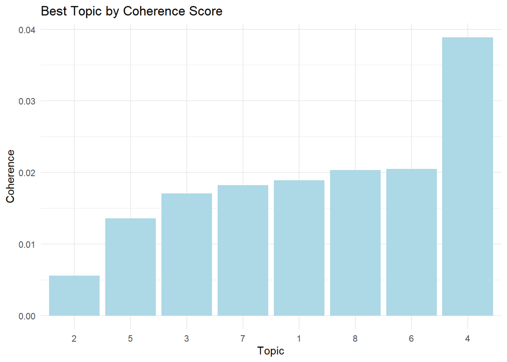

```r
k_list <- seq(1, 8, by = 1)
model_dir <- paste0("models_", digest::digest(dtm1, algo = "sha1"))
if (!dir.exists(model_dir)) dir.create(model_dir)
model_list <- TmParallelApply(X = k_list, FUN = function(k){
  filename = file.path(model_dir, paste0(k, "_topics.rda"))

  if (!file.exists(filename)) {
    m <- FitLdaModel(dtm = dtm1, k = k, iterations = 50)
    m$k <- k
    m$coherence <- CalcProbCoherence(phi = m$phi, dtm = dtm1, M = 5)
    save(m, file = filename)
  } else {
    load(filename)
  }

  m
}, export=c("dtm1", "model_dir")) # export only needed for Windows machines
#model tuning
#choosing the best model
coherence_mat <- data.frame(k = sapply(model_list, function(x) nrow(x$phi)),
                            coherence = sapply(model_list, function(x) mean(x$coherence)),
                            stringsAsFactors = FALSE)
ggplot(coherence_mat, aes(x = reorder(k, coherence), y = coherence)) +
  geom_bar(stat = "identity", fill = 'lightblue') +
  ggtitle("Best Topic by Coherence Score") + theme_minimal() + ylab("Coherence") +xlab('Topic')
```

According to the coherence score, the best k for this model is 4.

## Conclusion

For what concerns my research question, an important contribution would have been to go back from the topic allocation to the manifesto, in order to provide more information. Without this piece of information is difficult to set a clear answer.

## References

Latent Dirichlet Allocation in R. (Theses / Institute for Statistics and Mathematics; No. 2). WU Vienna University of Economics and Business.